# Análise de dados - Karina Sanjúan

## Objetivo do trabalho

O objetivo do trabalho foi avaliar se o tratamento de 6h e 10h de tempo de retenção do efluente é efetivo na redução da toxicidade. Para medir a toxicidade, foram utilizadas 3 métricas:

1. Toxicidade de algas;
2. Toxicidade de Ceriodaphinia;
3. Estrogenicidade;

Ainda, teve como objetivo avaliar se essas métricas de toxicidade tinham relação com alguns parâmetros limnológicos. Os parâmetros limnológicos utilizados foram:

1. DBO
2. DQO
3. DQOf
4. NKT
5. N-NH3
6. P - Fósforo
7. SST

### Design amostral

O design amostral utilizado foi o aninhado, pois a partir de uma coleta de esgoto, foram feitas em torno de 4 amostras para cada tempo. Sendo assim, as amostras foram coletadas como pseudo-réplicas, em vez de réplicas reais. Assim, o método estatístico utilizado para avaliar as relações foi a Anova aninhada.

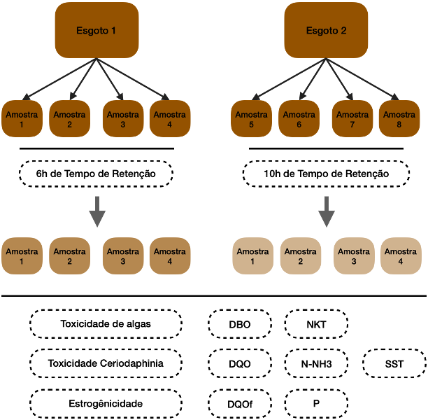

### Dados - Toxicidade de algas

Na tabela a seguir, podemos observar que houve um erro de amostragem pra uma amostra de 6h no grupo 3 (linha 12) e um erro no tratamento de 10h no grupo 4 (linha 13). Para corrigir esse erro, optamos por utilizar o método de inputação dos dados, utilizando o método de imputação múltipla MICE. Para mais detalhes : “https://blog.bringdata.co/dados-faltantes-o-que-sao-e-como-lidar/”

```r
data_algas1
```

|  | Semana | Grupos | Tempo | T_algas | DBO | DQO | DQOf | NKT | N.NH3 | P | SST |
| --- | --- | --- | --- | --- | --- | --- | --- | --- | --- | --- | --- |
| 1 | S1 | G1 | 6h | 8.70 | 61.29 | 267.75 | 145.25 | 64.07 | 57.46 | 6.57 | 59 |
| 2 | S2 | G1 | 6h | 4.41 | 52.44 | 226.50 | 137.75 | 64.37 | 52.14 | 6.03 | 44 |
| 3 | S3 | G1 | 6h | 2.54 | 61.93 | 225.25 | 105.25 | 68.32 | 56.26 | 5.64 | 53 |
| 4 | S4 | G1 | 6h | 9.64 | 19.34 | 236.50 | 110.25 | 69.35 | 61.77 | 6.85 | 51 |
| 5 | S1 | G2 | 10h | 5.72 | 26.89 | 89.00 | 39.00 | 101.90 | 91.64 | 7.90 | 45 |
| 6 | S2 | G2 | 10h | 8.25 | 29.49 | 117.25 | 74.75 | 67.42 | 62.09 | 8.37 | 54 |
| 7 | S3 | G2 | 10h | 9.08 | 23.94 | 85.25 | 31.50 | 87.04 | 80.17 | 9.40 | 33 |
| 8 | S4 | G2 | 10h | 3.23 | 33.65 | 96.50 | 30.67 | 67.30 | 61.93 | 7.02 | 34 |
| 9 | S1 | G3 | 6h | 0.10 | 22.82 | 80.75 | 65.75 | 81.05 | 68.50 | 7.39 | 21 |
| 10 | S2 | G3 | 6h | 2.61 | 21.48 | 94.50 | 54.50 | 58.20 | 47.51 | 6.02 | 16 |

[output cut: 6 more lines]

#### Imputando dados - Toxicidade aldas

A função a seguir, realiza a inputação dos dados:

```r
imputed_Data <- mice(data_algas1, m=1, maxit = 50, method = 'pmm', seed = 500)
summary(imputed_Data)
```

A tabela a seguir está completa agora:

```r
data_algas_input
```

|  | Semana | Grupos | Tempo | T_algas | DBO | DQO | DQOf | NKT | N.NH3 | P | SST |
| --- | --- | --- | --- | --- | --- | --- | --- | --- | --- | --- | --- |
| 1 | S1 | G1 | 6h | 8.70 | 61.29 | 267.75 | 145.25 | 64.07 | 57.46 | 6.57 | 59 |
| 2 | S2 | G1 | 6h | 4.41 | 52.44 | 226.50 | 137.75 | 64.37 | 52.14 | 6.03 | 44 |
| 3 | S3 | G1 | 6h | 2.54 | 61.93 | 225.25 | 105.25 | 68.32 | 56.26 | 5.64 | 53 |
| 4 | S4 | G1 | 6h | 9.64 | 19.34 | 236.50 | 110.25 | 69.35 | 61.77 | 6.85 | 51 |
| 5 | S1 | G2 | 10h | 5.72 | 26.89 | 89.00 | 39.00 | 101.90 | 91.64 | 7.90 | 45 |
| 6 | S2 | G2 | 10h | 8.25 | 29.49 | 117.25 | 74.75 | 67.42 | 62.09 | 8.37 | 54 |
| 7 | S3 | G2 | 10h | 9.08 | 23.94 | 85.25 | 31.50 | 87.04 | 80.17 | 9.40 | 33 |
| 8 | S4 | G2 | 10h | 3.23 | 33.65 | 96.50 | 30.67 | 67.30 | 61.93 | 7.02 | 34 |
| 9 | S1 | G3 | 6h | 0.10 | 22.82 | 80.75 | 65.75 | 81.05 | 68.50 | 7.39 | 21 |
| 10 | S2 | G3 | 6h | 2.61 | 21.48 | 94.50 | 54.50 | 58.20 | 47.51 | 6.02 | 16 |

[output cut: 6 more lines]

### Análises estatísticas - Anova aninhada

Para as análises, utilizamos um modelo com distribuição normal. Como variável resposta temos a toxicidade das algas e como variável preditora temos o tempo de retenção. Como as amostras estavam aninhadas, utilizamos o grupo como variável aleatória.

```r
mod1<-lmer(data_algas_input$T_algas ~ data_algas_input$Tempo + (1|data_algas_input$Grupos))
mod1
```

```
Linear mixed model fit by REML ['lmerMod']
Formula: data_algas_input$T_algas ~ data_algas_input$Tempo + (1 | data_algas_input$Grupos)
REML criterion at convergence: 74.1099
Random effects:
 Groups                  Name        Std.Dev.
 data_algas_input$Grupos (Intercept) 1.413
 Residual                            2.799
Number of obs: 16, groups:  data_algas_input$Grupos, 4
Fixed Effects:
             (Intercept)  data_algas_input$Tempo6h
                   4.915                     0.305
```

Utilizamos a função summary, para analisar alguns detalhes do modelo e dos resultados.

```r
summary(mod1)
```

```
Linear mixed model fit by REML ['lmerMod']
Formula: data_algas_input$T_algas ~ data_algas_input$Tempo + (1 | data_algas_input$Grupos)

REML criterion at convergence: 74.1

Scaled residuals:
    Min      1Q  Median      3Q     Max
-1.6306 -0.5960 -0.1463  0.9310  1.3805

Random effects:
 Groups                  Name        Variance Std.Dev.
 data_algas_input$Grupos (Intercept) 1.997    1.413
 Residual                            7.832    2.799
Number of obs: 16, groups:  data_algas_input$Grupos, 4

Fixed effects:
                         Estimate Std. Error t value
(Intercept)                 4.915      1.406   3.495
data_algas_input$Tempo6h    0.305      1.989   0.153

Correlation of Fixed Effects:
            (Intr)
dt_lgs_n$T6 -0.707
```

Já a função Anova nos mostra se a variável preditora teve efeito significativo ou não sobre a nossa variável resposta.

```r
Anova(mod1)
```

```
Analysis of Deviance Table (Type II Wald chisquare tests)

Response: data_algas_input$T_algas
                        Chisq Df Pr(>Chisq)
data_algas_input$Tempo 0.0235  1     0.8781
```

Aqui, podemos observar que o valor de P não foi significativo, pois foi maior que 0.05 (Pr(>Chisp) = 0.8781). Ou seja, o tempo de retenção do efluente não afetou os valores de toxicidade das algas. Podemos observar esse resultado visualmente, através do gráfico:

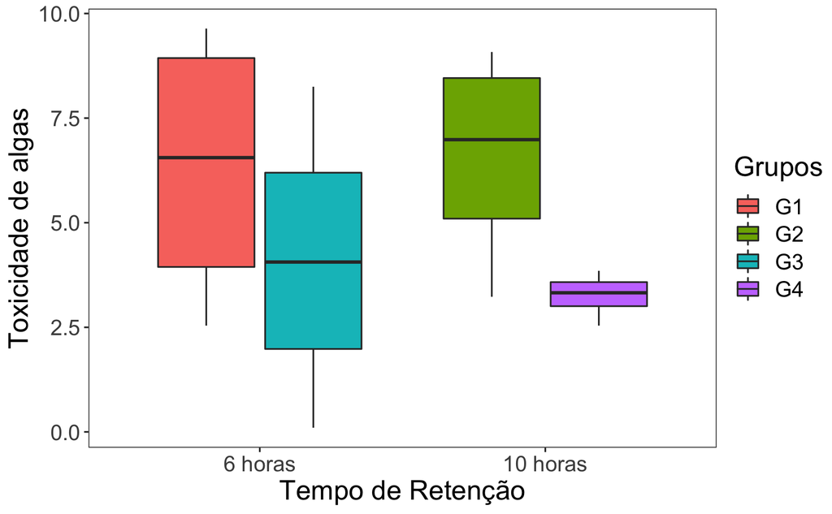

```r
ggplot(data_algas_input, aes(x = Tempo, y =T_algas, fill = Grupos))+
  theme_test()+
  theme(text = element_text(size=17))+
  scale_x_discrete("Tempo de Retenção", limits = c("6h", "10h"),
                   labels = c("6 horas", "10 horas"))+
  ylab("Toxicidade de algas")+
  geom_boxplot()
```

Agora, vamos avaliar a relação entre a toxicidade das algas e os parâmetros limnológicos coletados.

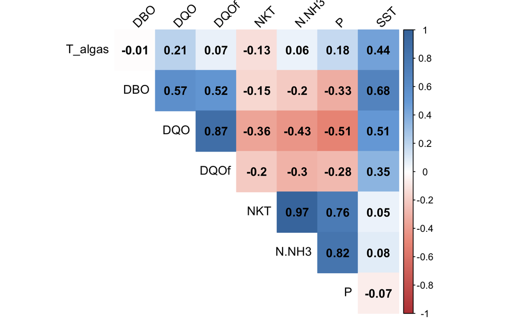

```r
corrplot(cor_algas, method="color", col=col(200),
         type="upper",
         addCoef.col = "black", # Adicionando coeficiente de correlação
         tl.col="black", tl.srt=45, #Text label color and rotation
         # Combinando com a significancia
         #p.mat = p.mat, sig.level = 0.01, insig = "blank",
         # Escondendo o coeficiente de correlação da diagonal principal(correlacao da variável com ela mesma)
         diag=FALSE)
```

### Dados - Toxicidade de Ceriodaphinia

Aqui podemos observar que para esses dados só existem dois grupos, e que ambos apresentam valores ausentes. Por isso, foi necessário utilizar o método de inputação MICE.

```r
data_ceri1
```

|  | Semana | Grupos | Tempo | T_Cerio | DBO | DQO | DQOf | NKT | N.NH3 | P | SST |
| --- | --- | --- | --- | --- | --- | --- | --- | --- | --- | --- | --- |
| 1 | S1 | G1 | 6h | 3.73 | 22.82 | 80.75 | 65.75 | 81.05 | 68.50 | 7.39 | 21 |
| 2 | S2 | G1 | 6h | 3.36 | 21.48 | 94.50 | 54.50 | 58.20 | 47.51 | 6.02 | 16 |
| 3 | S3 | G1 | 6h | 6.51 | 19.92 | 97.00 | 52.00 | 58.63 | 52.19 | 6.33 | 11 |
| 4 | S4 | G1 | 6h | NA | NA | NA | NA | NA | NA | NA | NA |
| 5 | S4 | G2 | 10h | NA | NA | NA | NA | NA | NA | NA | NA |
| 6 | S1 | G2 | 10h | 4.23 | 32.29 | 153.25 | 107.00 | 91.64 | 79.14 | 8.64 | 28 |
| 7 | S2 | G2 | 10h | 6.56 | 26.28 | 132.00 | 108.25 | 89.96 | 77.46 | 8.85 | 26 |
| 8 | S3 | G2 | 10h | 3.70 | 22.39 | 124.50 | 88.25 | 87.08 | 74.58 | 9.40 | 20 |

#### Inputando dados - Toxicidade de Ceriodaphinia

```r
imputed_Data2 <- mice(data_ceri1, m=5, maxit = 50, method = 'pmm', seed = 500)
summary(imputed_Data2)
```

Aqui está a tabela com os dados inputados:

```r
data_ceri_input
```

|  | Semana | Grupos | Tempo | T_Cerio | DBO | DQO | DQOf | NKT | N.NH3 | P | SST |
| --- | --- | --- | --- | --- | --- | --- | --- | --- | --- | --- | --- |
| 1 | S1 | G1 | 6h | 3.73 | 22.82 | 80.75 | 65.75 | 81.05 | 68.50 | 7.39 | 21 |
| 2 | S2 | G1 | 6h | 3.36 | 21.48 | 94.50 | 54.50 | 58.20 | 47.51 | 6.02 | 16 |
| 3 | S3 | G1 | 6h | 6.51 | 19.92 | 97.00 | 52.00 | 58.63 | 52.19 | 6.33 | 11 |
| 4 | S4 | G1 | 6h | 6.51 | 19.92 | 80.75 | 65.75 | 91.64 | 52.19 | 6.02 | 28 |
| 5 | S4 | G2 | 10h | 6.51 | 21.48 | 97.00 | 52.00 | 91.64 | 52.19 | 7.39 | 16 |
| 6 | S1 | G2 | 10h | 4.23 | 32.29 | 153.25 | 107.00 | 91.64 | 79.14 | 8.64 | 28 |
| 7 | S2 | G2 | 10h | 6.56 | 26.28 | 132.00 | 108.25 | 89.96 | 77.46 | 8.85 | 26 |
| 8 | S3 | G2 | 10h | 3.70 | 22.39 | 124.50 | 88.25 | 87.08 | 74.58 | 9.40 | 20 |

##### Análise de dados

Para as análises, utilizamos um modelo com distribuição normal. Como variável resposta temos a toxicidade de Ceriodaphinia e como variável preditora temos o tempo de retenção. No caso dos experimentos utilizados com Toxicidade de Ceriodaphinia apresentaram apenas um grupo pro tratamento de 6h e um grupo para o tratamento de 10h, não foi necessário a utilização de uma variável aleatória.

```r
mod2<-lm(data_ceri_input$T_Cerio ~ data_ceri_input$Tempo )
mod2
```

```
Call:
lm(formula = data_ceri_input$T_Cerio ~ data_ceri_input$Tempo)

Coefficients:
            (Intercept)  data_ceri_input$Tempo6h
                 5.2500                  -0.2225
```

Mais detalhes do modelo:

```r
summary(mod2)
```

```
Call:
lm(formula = data_ceri_input$T_Cerio ~ data_ceri_input$Tempo)

Residuals:
   Min     1Q Median     3Q    Max
-1.667 -1.361  0.120  1.353  1.482

Coefficients:
                        Estimate Std. Error t value Pr(>|t|)
(Intercept)               5.2500     0.8064   6.511 0.000626 ***
data_ceri_input$Tempo6h  -0.2225     1.1404  -0.195 0.851749
---
Signif. codes:  0 ‘***’ 0.001 ‘**’ 0.01 ‘*’ 0.05 ‘.’ 0.1 ‘ ’ 1

Residual standard error: 1.613 on 6 degrees of freedom
Multiple R-squared:  0.006304,  Adjusted R-squared:  -0.1593
F-statistic: 0.03807 on 1 and 6 DF,  p-value: 0.8517
```

Avaliando se o tempo tem efeito significativo na toxicidade de Ceriodaphinia:

```r
Anova(mod2)
```

```
Anova Table (Type II tests)

Response: data_ceri_input$T_Cerio
                      Sum Sq Df F value Pr(>F)
data_ceri_input$Tempo  0.099  1  0.0381 0.8517
Residuals             15.606  6
```

Aqui, podemos observar que o valor de P não foi significativo, pois foi maior que 0.05 (Pr(>Chisp) = 0.8517). Ou seja, o tempo de retenção do efluente não afetou os valores de toxicidade de Ceriodaphinia. Podemos observar esse resultado visualmente, através do gráfico:

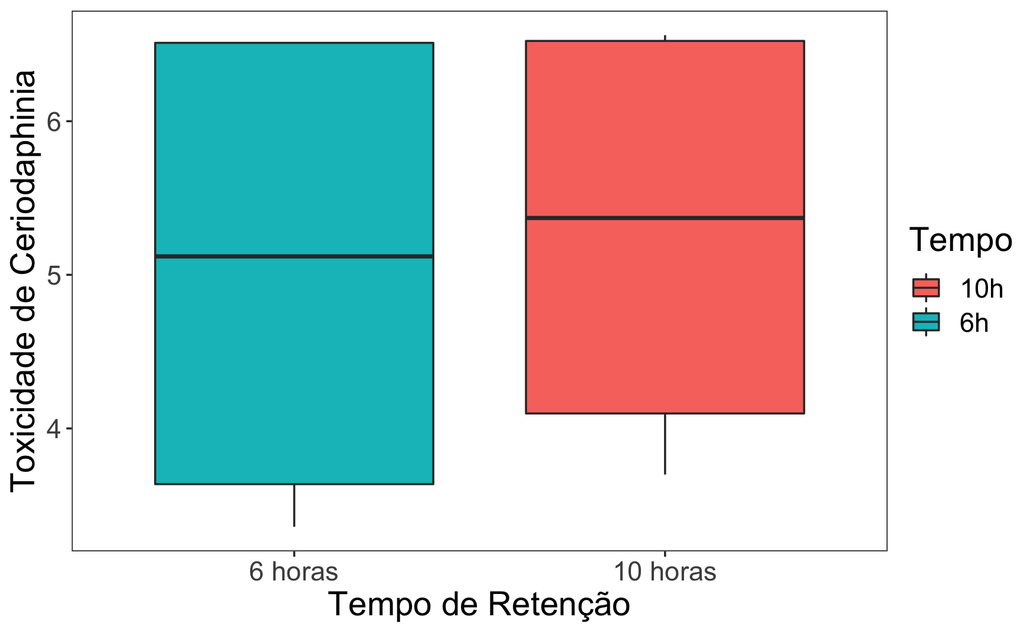

```r
ggplot(data_ceri_input, aes(x = Tempo, y =T_Cerio, fill = Tempo))+
  theme_test()+
  theme(text = element_text(size=17))+
  scale_x_discrete("Tempo de Retenção", limits = c("6h", "10h"),
                   labels = c("6 horas", "10 horas"))+
  ylab("Toxicidade de Ceriodaphinia")+
  geom_boxplot()
```

Agora, vamos avaliar a relação entre a toxicidade das Ceriodaphinias e os parâmetros limnológicos coletados.

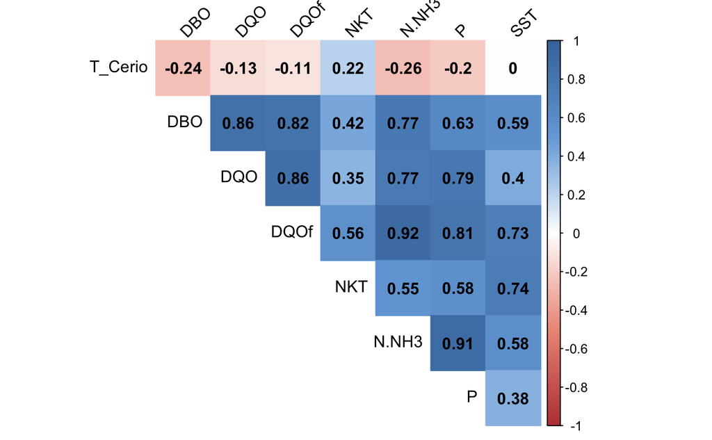

```r
corrplot(cor_ceri, method="color", col=col(200),
                      type="upper",
                      addCoef.col = "black", # Add coefficient of correlation
                      tl.col="black", tl.srt=45, #Text label color and rotation
                      # Combine with significance
                      #p.mat = p.mat, sig.level = 0.01, insig = "blank",
                      # hide correlation coefficient on the principal diagonal
                      diag=FALSE
)
```

Os resultados para correlação de Pearson mostraram que a Toxicidade de Ceriodaphinia não apresentou correlaçoes significativas com nenhum parâmetro limnológico avaliado.

#### Dados - Estrogenicidade

Tabela com os dados brutos. É possível observar que também existem dados faltates e portanto o método de inputação se faz necessário.

```r
data_estro1
```

|  | Semana | Grupos | Tempo | Estro | DBO | DQO | DQOf | NKT | N.NH3 | P | SST |
| --- | --- | --- | --- | --- | --- | --- | --- | --- | --- | --- | --- |
| 1 | S1 | G1 | 6h | 96 | 61.29 | 267.75 | 145.25 | 64.07 | 57.46 | 6.57 | 59 |
| 2 | S2 | G1 | 6h | 81 | 52.44 | 226.50 | 137.75 | 64.37 | 52.14 | 6.03 | 44 |
| 3 | S3 | G1 | 6h | 6 | 61.93 | 225.25 | 105.25 | 68.32 | 56.26 | 5.64 | 53 |
| 4 | S4 | G1 | 6h | 15 | 19.34 | 236.50 | 110.25 | 69.35 | 61.77 | 6.85 | 51 |
| 5 | S1 | G2 | 10h | 11 | 26.89 | 89.00 | 39.00 | 101.90 | 91.64 | 7.90 | 45 |
| 6 | S2 | G2 | 10h | 82 | 29.49 | 117.25 | 74.75 | 67.42 | 62.09 | 8.37 | 54 |
| 7 | S3 | G2 | 10h | 36 | 23.94 | 85.25 | 31.50 | 87.04 | 80.17 | 9.40 | 33 |
| 8 | S4 | G2 | 10h | 90 | 33.65 | 96.50 | 30.67 | 67.30 | 61.93 | 7.02 | 34 |
| 9 | S1 | G3 | 6h | 28 | 22.82 | 80.75 | 65.75 | 81.05 | 68.50 | 7.39 | 21 |
| 10 | S2 | G3 | 6h | 43 | 21.48 | 94.50 | 54.50 | 58.20 | 47.51 | 6.02 | 16 |

[output cut: 6 more lines]

#### Inputando os dados - Estrogenicidade

Como podemos observar no código abaixo, os métodos utilizados foram semelhantes aos realizados anteriormente para toxicidade de algas e Ceriodaphinia.

```r
imputed_Data3 <- mice(data_estro1, m=5, maxit = 50, method = 'pmm', seed = 500)
summary(imputed_Data3)
```

A seguir, a tabela com os dados inputados:

```r
data_estro_input
```

|  | Semana | Grupos | Tempo | Estro | DBO | DQO | DQOf | NKT | N.NH3 | P | SST |
| --- | --- | --- | --- | --- | --- | --- | --- | --- | --- | --- | --- |
| 1 | S1 | G1 | 6h | 96 | 61.29 | 267.75 | 145.25 | 64.07 | 57.46 | 6.57 | 59 |
| 2 | S2 | G1 | 6h | 81 | 52.44 | 226.50 | 137.75 | 64.37 | 52.14 | 6.03 | 44 |
| 3 | S3 | G1 | 6h | 6 | 61.93 | 225.25 | 105.25 | 68.32 | 56.26 | 5.64 | 53 |
| 4 | S4 | G1 | 6h | 15 | 19.34 | 236.50 | 110.25 | 69.35 | 61.77 | 6.85 | 51 |
| 5 | S1 | G2 | 10h | 11 | 26.89 | 89.00 | 39.00 | 101.90 | 91.64 | 7.90 | 45 |
| 6 | S2 | G2 | 10h | 82 | 29.49 | 117.25 | 74.75 | 67.42 | 62.09 | 8.37 | 54 |
| 7 | S3 | G2 | 10h | 36 | 23.94 | 85.25 | 31.50 | 87.04 | 80.17 | 9.40 | 33 |
| 8 | S4 | G2 | 10h | 90 | 33.65 | 96.50 | 30.67 | 67.30 | 61.93 | 7.02 | 34 |
| 9 | S1 | G3 | 6h | 28 | 22.82 | 80.75 | 65.75 | 81.05 | 68.50 | 7.39 | 21 |
| 10 | S2 | G3 | 6h | 43 | 21.48 | 94.50 | 54.50 | 58.20 | 47.51 | 6.02 | 16 |

[output cut: 6 more lines]

##### Análise de dados - Anova aninhada

Assim como para as análises de toxicidade de algas, os dados presentes para Estrogenicidade são aninhados em quatro grupos. Assim, se faz necessário a utilização de uma variável aleatório no nosso modelo.

```r
mod3<-lmer(data_estro_input$Estro ~ data_estro_input$Tempo + (1|data_estro_input$Grupos))
mod3
```

```
Linear mixed model fit by REML ['lmerMod']
Formula: data_estro_input$Estro ~ data_estro_input$Tempo + (1 | data_estro_input$Grupos)
REML criterion at convergence: 140.2502
Random effects:
 Groups                  Name        Std.Dev.
 data_estro_input$Grupos (Intercept)  2.882
 Residual                            31.158
Number of obs: 16, groups:  data_estro_input$Grupos, 4
Fixed Effects:
             (Intercept)  data_estro_input$Tempo6h
                   41.62                     -1.00
```

Mais detalhes sobre o modelo:

```r
summary(mod3)
```

```
Linear mixed model fit by REML ['lmerMod']
Formula: data_estro_input$Estro ~ data_estro_input$Tempo + (1 | data_estro_input$Grupos)

REML criterion at convergence: 140.3

Scaled residuals:
    Min      1Q  Median      3Q     Max
-1.1207 -0.7421 -0.2812  0.5807  1.7678

Random effects:
 Groups                  Name        Variance Std.Dev.
 data_estro_input$Grupos (Intercept)   8.306   2.882
 Residual                            970.807  31.158
Number of obs: 16, groups:  data_estro_input$Grupos, 4

Fixed effects:
                         Estimate Std. Error t value
(Intercept)                 41.62      11.20   3.716
data_estro_input$Tempo6h    -1.00      15.84  -0.063

Correlation of Fixed Effects:
            (Intr)
dt_str_n$T6 -0.707
```

Avaliando a relação entre tempo e Estrogenicidade

```r
Anova(mod3)
```

```
Analysis of Deviance Table (Type II Wald chisquare tests)

Response: data_estro_input$Estro
                       Chisq Df Pr(>Chisq)
data_estro_input$Tempo 0.004  1     0.9497
```

Aqui, podemos observar que o valor de P não foi significativo, pois foi maior que 0.05 (Pr(>Chisp) = 0.9497). Ou seja, o tempo de retenção do efluente não afetou os valores de Estrogenicidade. Podemos observar esse resultado visualmente, através do gráfico:

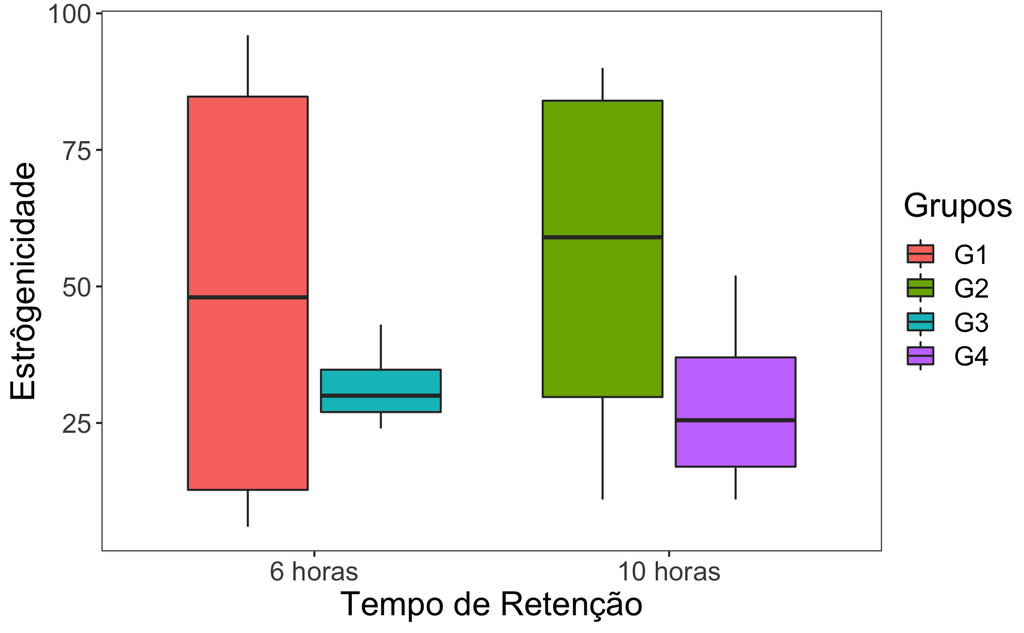

```r
ggplot(data_estro_input, aes(x = Tempo, y = Estro, fill = Grupos))+
  theme_test()+
  theme(text = element_text(size=17))+
  scale_x_discrete("Tempo de Retenção", limits = c("6h", "10h"),
                   labels = c("6 horas", "10 horas"))+
  ylab("Estrôgenicidade")+
  geom_boxplot()
```

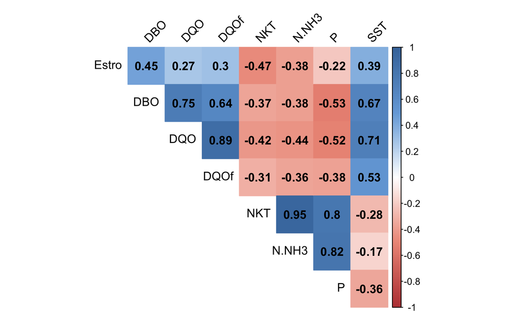

```r
cor_estro1<- corrplot(cor_estro, method="color", col=col(200),
                     type="upper",
                     addCoef.col = "black", # Add coefficient of correlation
                     tl.col="black", tl.srt=45, #Text label color and rotation
                     # Combine with significance
                     #p.mat = p.mat, sig.level = 0.01, insig = "blank",
                     # hide correlation coefficient on the principal diagonal
                     diag=FALSE
)
```

Aqui podemos observar que a Estrogenicidade apresentou valores de correlação um pouco maior que as outras variáveis avaliadas anteriormente. Porém, nenhuma dessas relações foram significativas

#### Observações

Aqui vale ressaltar que aparece uma mensagem de alerta em alguns modelos “unable to evaluate scaled gradient Hessian is numerically singular: parameters are not uniquely determined”. Esse problema pode estar relacionada ao balanceamento dos seus dados e tamanho do seu banco de dados. Ou seja, para melhorar as estimativas do modelo, o ideal seria aumentar o número de amostras do seu experimento.  
Para mais detalhes: “https://stats.stackexchange.com/questions/187841/how-to-deal-with-clmm-warning-hessian-is-numerically-singular”